# BioQC p-value distributions on real-world data.

We load gene expression data from various GEO studies.

```r
# real world studies
load("/pstore/data/biostats/users/sturmg/BioQC_GEO_analysis/gse_tissue_annot/geo_annot/GSE33828.Rdata")
gse33828 = eset_res
load("/pstore/data/biostats/users/sturmg/BioQC_GEO_analysis/gse_tissue_annot/geo_annot/GSE40773.Rdata")
gse40773 = eset_res
load("/pstore/data/biostats/users/sturmg/BioQC_GEO_analysis/gse_tissue_annot/geo_annot/GSE48152.Rdata")
gse48152 = eset_res
load("/pstore/data/biostats/users/sturmg/BioQC_GEO_analysis/gse_tissue_annot/geo_annot/GSE47199.Rdata")
gse47199 = eset_res
load("/pstore/data/biostats/users/sturmg/BioQC_GEO_analysis/gse_tissue_annot/geo_annot/GSE68172.Rdata")
gse68172 = eset_res
load("/pstore/data/biostats/users/sturmg/BioQC_GEO_analysis/gse_tissue_annot/geo_annot/GSE33580.Rdata")
gse33580 = eset_res
```

We load the set of `baseline_signatures`, containing housekeeping signatures and random signatures. The random signatures are sets of different lengths randomly drawn from the universe of all HGNC gene symbols.

```r
baseline_signatures = readGmt("../pygenesig/results/baseline_signatures.gmt")
```

## P-Value distribution for GSE33828

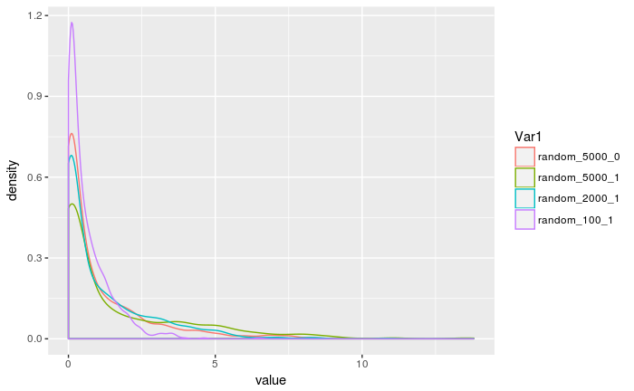

```r
bioqc_res = absLog10p(wmwTest(gse33828, baseline_signatures, valType="p.greater", col="BioqcGeneSymbol"))
ggplot(melt(bioqc_res[c("random_5000_0","random_5000_1", "random_2000_1", "random_100_1"),]), aes(x=value)) + geom_density(aes(color=Var1))
```

## P-Value distribution for GSE33580

On this study, we notice a strong bias towards long signatures. `random_5000_1` scores systematically with a median score of 3.5.

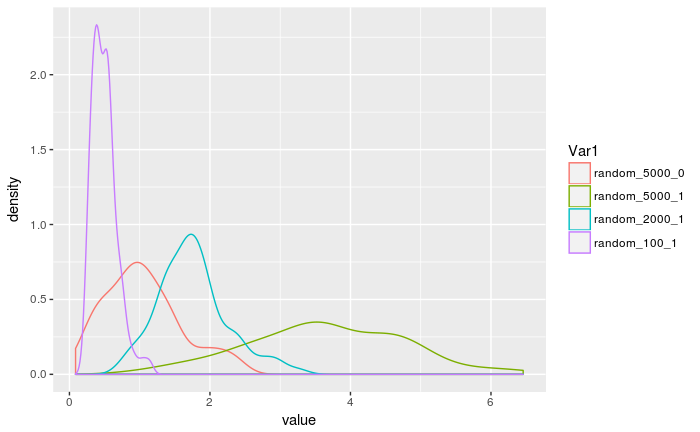

```r
bioqc_res = absLog10p(wmwTest(gse33580, baseline_signatures, valType="p.greater", col="BioqcGeneSymbol"))
ggplot(melt(bioqc_res[c("random_5000_0","random_5000_1", "random_2000_1", "random_100_1"),]), aes(x=value)) + geom_density(aes(color=Var1))
```

Still, using random signature generated on-the-fly in R (using gene indices, not gene symbols) the distribution is as expected, while for `random_5000_1` the score is systematically way too high.

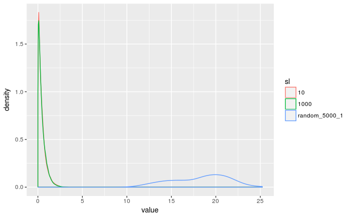

```r
N_SIG = 2000
N_GENES_PER_SIG = 10
sample_data = gse33580
sample_mat = exprs(sample_data)
N_GENES = nrow(exprs(sample_data))
sig5000 = baseline_signatures$random_5000_1$genes
sig_list10 = lapply(1:N_SIG, function(unused) {return(sample(1:(N_GENES), 10))})
sig_list1000 = lapply(1:N_SIG, function(unused) {return(sample(1:(N_GENES), 1000))})
sig_list_baseline = list(sig5000=fData(sample_data)$BioqcGeneSymbol %in% sig5000)
bioqc_res_10 = data.table(melt(absLog10p(wmwTest(sample_mat, sig_list10, valType="p.greater"))))
bioqc_res_1000 = data.table(melt(absLog10p(wmwTest(sample_mat, sig_list1000, valType="p.greater"))))
bioqc_res_baseline = data.table(melt(absLog10p(wmwTest(sample_mat, sig_list_baseline, valType="p.greater"))))
bioqc_res_10[,sl:="10"]
bioqc_res_1000[,sl:="1000"]
bioqc_res_baseline[,sl:="random_5000_1"]
res_molten = rbind(bioqc_res_10, bioqc_res_1000, bioqc_res_baseline, fill=TRUE)
ggplot(res_molten, aes(x=value)) + geom_density(aes(color=sl))
```

## The abundance of signatures based on gene symbols tends to be overestimated, if the whole expression matrix is used as background.

As annotated genes tend to be those that have in general a higher expression level, a random signature using gene symbols will be over-represented in this sample. This is a problem in particular, if an expression set contains a lot of probesets without a gene symbol (e.g. GSE33580).

We correct for that by limiting the background to all genes with a gene symbol. We have implemented a function `filter_eset` for this purpose.

```r
filter_eset
```

```
function(eset) {
  gene_symbols = fData(eset)$BioqcGeneSymbol
  hgnc_symbols = invisible(read_tsv("lib/res/hgnc_symbols.tsv"))
  # remove lines that have no or an invalid gene symbol
  eset = eset[(!is.na(gene_symbols)) & (gene_symbols != '-') & (gene_symbols %in% hgnc_symbols$hgnc_symbols),]
  eset = eset[keepMaxStatRowInd(exprs(eset), fData(eset)$BioqcGeneSymbol),]
  return(eset)
}
```

## corrected P-Value distribution for GSE33580

After the correction the-pvalue distributions of the random signatures are significantly lower and more uniform. While `random_5000_1` still scores highest, `random_5000_0` scores lowest, showing that this is random noise and not systematic any more.

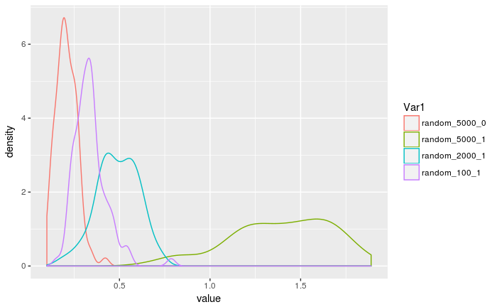

```r
gse33580_filtered = filter_eset(gse33580)
bioqc_res = absLog10p(wmwTest(gse33580_filtered, baseline_signatures, valType="p.greater", col="BioqcGeneSymbol"))
ggplot(melt(bioqc_res[c("random_5000_0","random_5000_1", "random_2000_1", "random_100_1"),]), aes(x=value)) + geom_density(aes(color=Var1))
```

## P-Value distribution over the whole database.

As a final check, we show the p-value distribution of different random signatures over the whole database of GEO studies, after this correction has been applied.

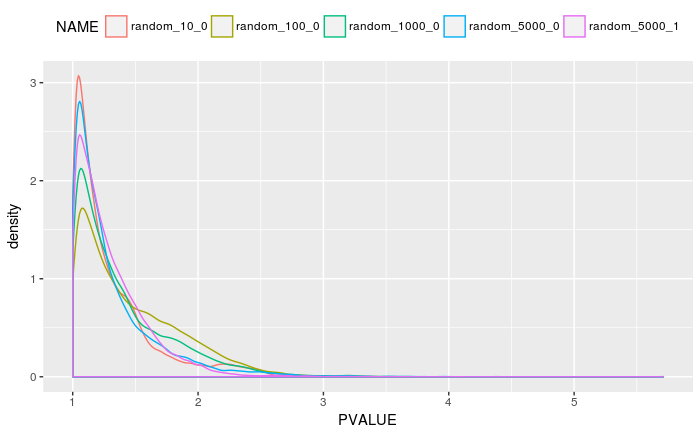

```r
sql = "
select /*+ parallel(16) */  br.signature
                          , bs.name
                          , br.gsm
                          , br.pvalue
from bioqc_signatures bs
join bioqc_res br on br.signature = bs.id
where source = 'baseline_signatures.gmt'
and bs.name in ('random_10_0', 'random_100_0', 'random_1000_0', 'random_5000_0', 'random_5000_1')
"
density = data.table(dbGetQuery(mydb, sql))
density[,PVALUE:=absLog10p(as.numeric(PVALUE))]
ggplot(density, aes(x=PVALUE)) + geom_density(aes(color=NAME)) + theme(legend.position = "top")
```